# Analysis of Activity Monitoring Data

Naveen Payallametta

September 2, 2016

# **Below is the R Code**

*Loading the activity dataset into R*

```r
setwd("C:\\Users\\user\\Documents\\R")
activity_analysis=read.csv("activity.csv",header=TRUE)
activity_analysis$date=as.Date(activity_analysis$date)
summary(activity_analysis)
```

```
##      steps             date               interval
##  Min.   :  0.00   Min.   :2012-10-01   Min.   :   0.0
##  1st Qu.:  0.00   1st Qu.:2012-10-16   1st Qu.: 588.8
##  Median :  0.00   Median :2012-10-31   Median :1177.5
##  Mean   : 37.38   Mean   :2012-10-31   Mean   :1177.5
##  3rd Qu.: 12.00   3rd Qu.:2012-11-15   3rd Qu.:1766.2
##  Max.   :806.00   Max.   :2012-11-30   Max.   :2355.0
##  NA's   :2304
```

**The above summary shows that there are 2304 NA’s in ‘steps’ variable**

## Calculation of Mean, Median of total number of steps taken per day:

*Step1:Calculation of total number of steps taken per day:*

```r
library(plyr)
perDay=ddply(activity_analysis,"date",summarize, sum=sum(steps))
```

*Step2:Calculation of Mean of the total number of steps taken per day:*

```r
mean_perDay=round(mean(perDay$sum,na.rm=TRUE))
mean_perDay
```

```
## [1] 10766
```

*Step3:Calculation of the Median of the total number of steps taken per day:*

```r
median_perDay=median(perDay$sum,na.rm=TRUE)
median_perDay
```

```
## [1] 10765
```

### Report: A histogram with density curve of the average number of steps taken per day is shown below.

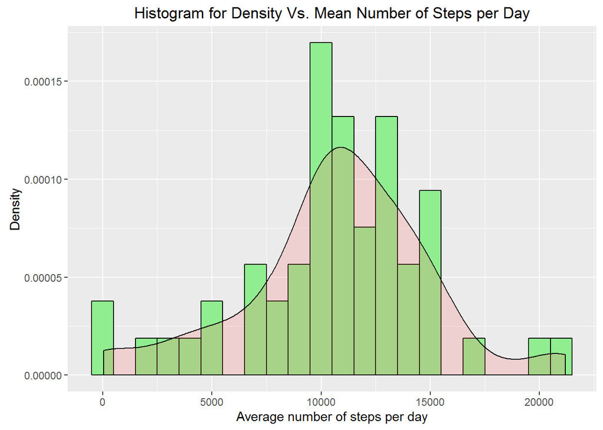

```r
library(ggplot2)
ggplot(perDay, aes(x=sum))+ geom_histogram(aes(y=..density..),binwidth=1000,
                                           colour="black", fill="lightgreen") + geom_density(alpha=.2, fill="#FF6666")+
  labs(title="Histogram for Density Vs. Mean Number of Steps per Day")+
  labs(x="Average number of steps per day",y="Density")
```

## Average Daily Activity Pattern:

### Time series plot of the 5-minute interval and the average number of steps taken, averaged across all days.

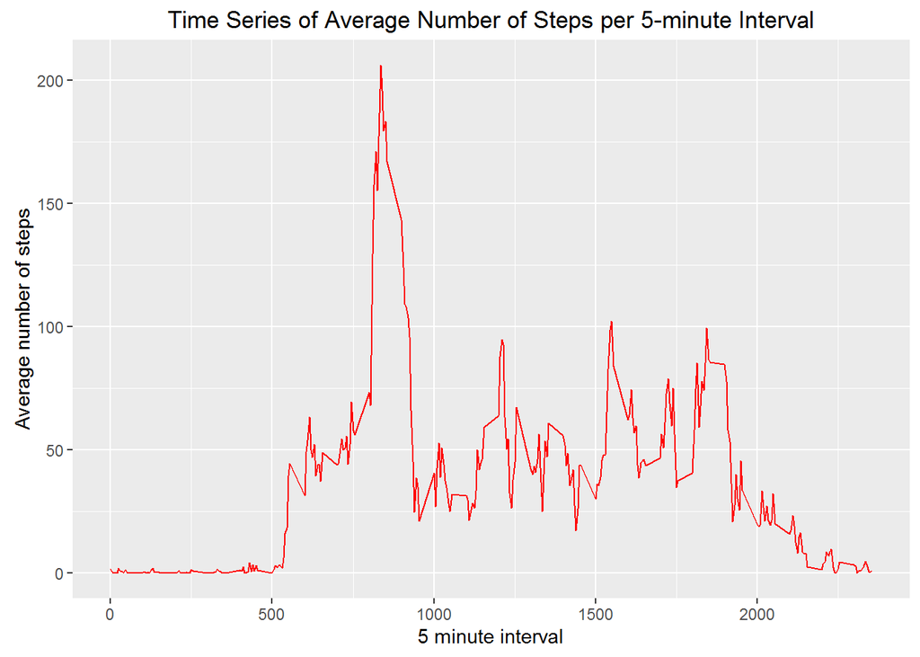

```r
byIntervel=ddply(activity_analysis,"interval",summarize, avg=mean(steps,na.rm=TRUE))
ggplot(byIntervel, aes(x = interval, y = avg, group = 1))+ geom_line(colour="red")+
  labs(title="Time Series of Average Number of Steps per 5-minute Interval")+
  labs(x="5 minute interval",y="Average number of steps")
```

```r
which.max(byIntervel[,2])
```

```
## [1] 104
```

```r
maxIntervel=round(byIntervel[104,])
maxIntervel
```

```
##     interval avg
## 104      835 206
```

### Imputing Missing Values:

*Step1: Calculation of the total number of missing values in the dataset (i.e. the total number of rows with NAs)*

```r
missing_values=sum(is.na(activity_analysis))
n=nrow(activity_analysis)
missing_values
```

```
## [1] 2304
```

*Step2: Replacing the missing value with the mean of the corresponding 5-minute interval variable.*

```r
library(Hmisc)
activity_imputed = ddply(activity_analysis, "interval", mutate,imputed_steps = impute(steps, mean))
```

*Step3: Created a new dataset “activity_new” that is equal to the original dataset but with the missing data filled in.*

```r
activity_final=activity_imputed[order(activity_imputed[,2],decreasing=FALSE),]
activity_new=activity_final[,c(4,2,3)]
detach("package:Hmisc")
summary(activity_new)
```

```
##
##  8 values imputed to 1.716981
```

```
##  imputed_steps         date               interval
##  Min.   :  0.00   Min.   :2012-10-01   Min.   :   0.0
##  1st Qu.:  0.00   1st Qu.:2012-10-16   1st Qu.: 588.8
##  Median :  0.00   Median :2012-10-31   Median :1177.5
##  Mean   : 37.38   Mean   :2012-10-31   Mean   :1177.5
##  3rd Qu.: 27.00   3rd Qu.:2012-11-15   3rd Qu.:1766.2
##  Max.   :806.00   Max.   :2012-11-30   Max.   :2355.0
```

*Step4: A histogram with density curve of the new dataset with imputed missing values is shown below.*

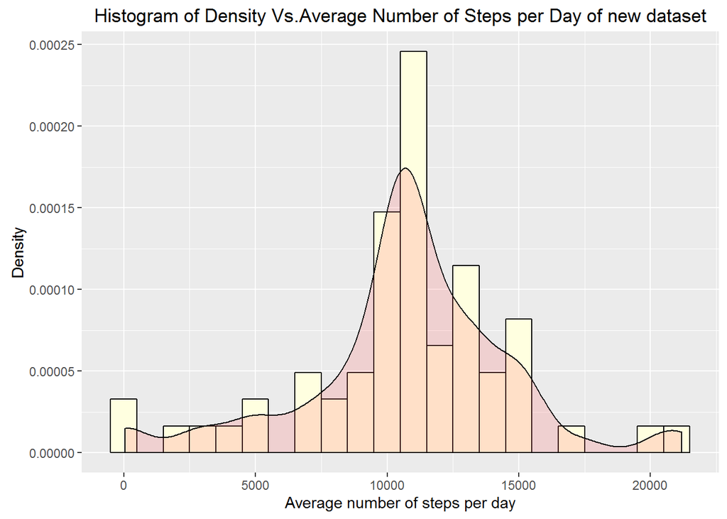

```r
perDay_new=ddply(activity_new,"date",summarize, sum=sum(imputed_steps))

ggplot(perDay_new, aes(x=sum)) +theme_set(theme_bw())+ geom_histogram(aes(y=..density..),binwidth=1000,
                                                                      colour="black", fill="lightyellow") + geom_density(alpha=.2, fill="#FF6666")+
  labs(title="Histogram of Density Vs.Average Number of Steps per Day of new dataset")+ labs(x="Average number of steps per day",y="Density")
```

```r
mean_imp=round(mean(perDay_new$sum,na.rm=TRUE))
mean_imp
```

```
## [1] 10766
```

```r
median_imp=median(perDay_new$sum,na.rm=TRUE)
median_imp
```

```
## [1] 10766.19
```

### From the histogram it appears that replacing the missing values with the means of that 5-minute interval have concentrated the average total number of steps per day around 10000 steps.

## Differences in activity patterns between weekdays and weekends:

*Step1: Creating a new factor variable in the dataset with two levels - “weekday” and “weekend” indicating whether a given date is a weekday or weekend day.*

```r
activity_new$wend = as.factor(ifelse(weekdays(activity_new$date) %in%
                                       c("Saturday","Sunday"), "Weekend", "Weekday"))
activity_Weekend=subset(activity_new,wend=="Weekend")
activity_Weekday=subset(activity_new,wend=="Weekday")

byWeekend_imp=ddply(activity_Weekend,"interval",summarize, avg=mean(imputed_steps))
byWeekday_imp=ddply(activity_Weekend,"interval",summarize, avg=mean(imputed_steps))
```

```r
library(gridExtra)
```

[figure not shown]

```r
plotWD=ggplot(byWeekday_imp, aes(x = interval, y = avg, group = 1))+ylim(0,250)+geom_line(colour="salmon")+
  labs(title="Average Number of Steps per 5-minute Intervals during Weekdays")+
  labs(x="5 minute interval",y="Average number of steps")
plotWD=plotWD+theme(plot.margin=unit(c(0,1,0,1), "cm"))

plotWE=ggplot(byWeekend_imp, aes(x = interval, y = avg, group = 1))+ylim(0,250)+geom_line(colour="blue")+
  labs(title="Average Number of Steps per 5-minute Intervals during Weekends")+
  labs(x="5 minute interval",y="Average number of steps")
plotWE=plotWE+theme(plot.margin=unit(c(0,1,0,1), "cm"))

grid.arrange(plotWE, plotWD, nrow=2, ncol=1)
```